# Binary choices: interpreting probit and logit

Chapter 16, Lecture 1

**Anchor decision:** How does Coke’s price relative to Pepsi’s change the probability of choosing Coke?  
Does a Coke display change the response to price?

The lab uses the original **Coke–Pepsi data (1,140 observations)** from Principles of Econometrics. All code on this page is executed, so results and figures appear as we scroll.  
`lecture_16_1.R` contains the same code as a stand-alone script, and also saves the figures to `figures/`.

## Outcomes and preparation

After this lecture you can (1) derive the probit and logit choice probabilities from a latent-variable or random-utility model and state what is and is not identified, (2) derive and interpret predicted probabilities, conditional slopes, odds ratios and elasticities, (3) distinguish a dummy-variable comparison from a derivative and a finite change from a tangent, and (4) evaluate an interaction on both the probability and the log-odds scale.

**Before class:** read textbook §§16.1–16.2.4 and work through the collapsed *Derivation* boxes under results R1–R8 below.  
In class we state the results and use them; we do not re-derive them on the board.  
Appendices A–C (likelihood geometry, delta method, the Gumbel-to-logit step) are reference material that goes beyond the textbook.

## 0. Retrieval

If `coke = 1` for a Coke purchase and zero otherwise, why does $E(\text{coke}\mid X)$ equal $P(\text{coke}=1\mid X)$, and what is $\operatorname{Var}(\text{coke}\mid X)$?

**Answer**

**Answer:** $E(y\mid X)=0\cdot(1-p)+1\cdot p=p$,  
and since $y^2=y$,  
$\operatorname{Var}(y\mid X)=E(y^2\mid X)-p^2=p(1-p)$.  
We model a conditional mean that must lie between zero and one, and the variance is a known function of that mean.  
The weight $p(1-p)$ will reappear three times today:  
in the logit slope,  
in the curvature of the probability curve,  
and in the variance of the estimator.

## 1. Hook

Before any calculation, vote: if the Coke-to-Pepsi price ratio increases by 0.1, is the predicted probability change the same for a shopper whose starting probability is 0.2 as one whose probability is 0.5?  
Would adding a Coke display change the price response by a constant number of percentage points?  
Record both predictions.

## 2. Theory

Throughout, let

$$\eta_i=\mathbf{x}_i'\boldsymbol\beta=\alpha+\beta_P x_i+\beta_C d_i+\beta_{Pe}q_i ,$$

where $x$ is the Coke-to-Pepsi price ratio, $d$ is a Coke-display indicator, and $q$ is a Pepsi-display indicator.  
The model is $p_i=P(y_i=1\mid\mathbf{x}_i)=F(\eta_i)$ with $F$ a CDF and $f=F'$ its density.  
Probit uses $F=\Phi$, $f=\phi$; logit uses $F=\Lambda(\eta)=1/(1+e^{-\eta})$, $f=\lambda$.

### R1 · Where the CDF comes from, and what is identified

**Latent-variable form.** Let $y_i^*=\mathbf{x}_i'\boldsymbol\beta+\varepsilon_i$ with $\varepsilon_i$ independent of $\mathbf{x}_i$, symmetric around zero with CDF $F$, and observe $y_i=\mathbf{1}\{y_i^*>0\}$.  
Then

$$P(y_i=1\mid\mathbf{x}_i)=P(\varepsilon_i>-\mathbf{x}_i'\boldsymbol\beta)=1-F(-\mathbf{x}_i'\boldsymbol\beta)=F(\mathbf{x}_i'\boldsymbol\beta).$$

**Random-utility form.** Let $U_{iC}=V_{iC}+\varepsilon_{iC}$ and $U_{iP}=V_{iP}+\varepsilon_{iP}$.  
The shopper buys Coke if $U_{iC}>U_{iP}$, so $y_i^*=(V_{iC}-V_{iP})+(\varepsilon_{iC}-\varepsilon_{iP})$.  
Jointly normal errors give probit; independent type-I extreme-value (Gumbel) errors give a logistic difference and hence logit (Appendix C).  
Only *utility differences* enter, which is why alternative-invariant shopper characteristics can enter only through their effect on the difference.  
Note that utility linear in own price, $V_{iC}=\ldots+\gamma P_{iC}$ and $V_{iP}=\ldots+\gamma P_{iP}$, puts the price *difference* $P_C-P_P$ into the index, not the ratio.  
Using the ratio $x=P_C/P_P$ follows the textbook’s convention; the generic price coefficient $\gamma$ returns with conditional logit in Lecture 2.

**Identification.** If $\varepsilon_i=\sigma u_i$, then $y_i=\mathbf{1}\{\mathbf{x}_i'(\boldsymbol\beta/\sigma)+u_i>0\}$: the data identify $\boldsymbol\beta/\sigma$, never $\boldsymbol\beta$ and $\sigma$ separately.  
Probit normalizes $\operatorname{Var}(u)=1$; logit normalizes $\operatorname{Var}(u)=\pi^2/3$.  
Likewise the threshold 0 is absorbed into the intercept.  
Two consequences:

1. **Raw coefficients are not comparable across links.** Matching variances suggests $\beta_{\text{logit}}\approx(\pi/\sqrt3)\beta_{\text{probit}}\approx1.81\,\beta_{\text{probit}}$; matching densities at the centre, where most data lie, gives $\phi(0)/\lambda(0)=0.399/0.25\approx1.6$.  
   That is the textbook’s rule of thumb.
2. **Coefficient ratios are identified under either normalization.** Because $p$ depends on $\mathbf{x}$ only through $\eta$, iso-probability contours are $d\eta=0$.
   Holding the Coke-choice probability fixed, a Coke display is worth
   $$\Delta x\big|_{\Delta p=0}=-\frac{\beta_C}{\beta_P}$$
   units of price ratio.
   This is a marginal rate of substitution between price and display, and it has economic units.
   The scale $\sigma$ cancels, so the two links differ here only through how well $F$ fits: fitted ratios are close, but not identical.

**Derivation R1: symmetry and identification up to scale**

Without symmetry, $P(y=1\mid\mathbf{x})=1-F(-\mathbf{x}'\boldsymbol\beta)$, which is still a valid CDF of $-\varepsilon$ evaluated at $\mathbf{x}'\boldsymbol\beta$.  
Symmetry only lets us write it compactly as $F(\mathbf{x}'\boldsymbol\beta)$.  
Both the normal and logistic are symmetric.

For scale, the event $\{\mathbf{x}'\boldsymbol\beta+\sigma u>0\}$ equals $\{\mathbf{x}'(c\boldsymbol\beta)+c\sigma u>0\}$ for every $c>0$.  
The pairs $(\boldsymbol\beta,\sigma)$ and $(c\boldsymbol\beta,c\sigma)$ generate identical distributions of $y\mid\mathbf{x}$, so no amount of data can separate them.  
For location, replacing the threshold 0 by $\tau$ gives $\{(\alpha-\tau)+\ldots+\varepsilon>0\}$: only $\alpha-\tau$ is identified.

Ratios cancel the scale: $(\beta_k/\sigma)/(\beta_l/\sigma)=\beta_k/\beta_l$.  
Along an iso-probability contour, $\beta_P\,dx+\beta_C\,\Delta d=0$, which gives the display-equivalent price change above.

### R2 · Logit is linear in the log-odds

Solving $p=\Lambda(\eta)$ for $\eta$ gives

$$\ln\frac{p}{1-p}=\eta=\alpha+\beta_P x+\beta_C d+\beta_{Pe}q .$$

So $\beta_k$ is the constant change in the **log-odds** per unit of $x_k$, and $e^{\beta_k}$ is an **odds ratio**: switching on the Coke display multiplies the odds of Coke by $e^{\beta_C}$, at every price and for every shopper.  
A 0.1 increase in the price ratio multiplies the odds by $e^{0.1\beta_P}$.  
Odds ratios are not probability changes; converting back requires a baseline $p$.  
Probit has no equally simple scale on which it is linear except the latent index itself.

**Derivation R2**

$p=1/(1+e^{-\eta})\Rightarrow 1-p=e^{-\eta}/(1+e^{-\eta})\Rightarrow p/(1-p)=e^{\eta}$.  
Taking logs gives the result.  
For two profiles differing only in $x_k$ by one unit, the ratio of odds is $e^{\eta+\beta_k}/e^{\eta}=e^{\beta_k}$, independent of $\eta$.

### R3 · The marginal effect is a chain rule

$$\frac{\partial p_i}{\partial x_i}=\frac{dF(\eta_i)}{d\eta_i}\,\frac{\partial\eta_i}{\partial x_i}=f(\eta_i)\,\beta_P,
\qquad
\text{logit: }\frac{\partial p_i}{\partial x_i}=p_i(1-p_i)\,\beta_P .$$

The density supplies the changing steepness of the CDF.  
The sign always equals the sign of $\beta_P$ because $f>0$; the magnitude depends on where shopper $i$ sits on the curve.  
A slope is in probability units for a **one-unit** change in the price ratio; multiply by 100 for percentage points.

**Derivation R3: the logistic density**

$$\lambda(\eta)=\frac{d}{d\eta}\frac{1}{1+e^{-\eta}}=\frac{e^{-\eta}}{(1+e^{-\eta})^2}
=\underbrace{\frac{1}{1+e^{-\eta}}}_{\Lambda(\eta)}\cdot\underbrace{\frac{e^{-\eta}}{1+e^{-\eta}}}_{1-\Lambda(\eta)} .$$

So $\lambda=\Lambda(1-\Lambda)=p(1-p)$: the logit slope is the Bernoulli variance times the coefficient.  
For probit there is no such simplification; $\phi(\eta)=(2\pi)^{-1/2}e^{-\eta^2/2}$ must be evaluated at $\eta=\Phi^{-1}(p)$.

### R4 · Two useful consequences of R3

**An upper bound.** Both densities peak at $\eta=0$ ($p=0.5$), so

$$\left|\frac{\partial p}{\partial x_k}\right|\le f(0)\,|\beta_k|=
\begin{cases}0.25\,|\beta_k| & \text{logit}\\ 0.399\,|\beta_k| & \text{probit.}\end{cases}$$

Dividing a logit coefficient by 4 is a quick and safe upper bound on any probability slope, and it is nearly exact for shoppers close to $p=0.5$.

**Relative effects are constant.** For two continuous regressors, $(\partial p/\partial x_k)/(\partial p/\partial x_l)=\beta_k/\beta_l$ for every shopper, because $f(\eta_i)$ cancels.  
The *ranking* of continuous regressors’ local effects is therefore the same everywhere.  
Only the level varies.  
In today’s model `pratio` is the only continuous regressor, so this result has nothing to compare here; keep it for models with several prices or incomes.

### R5 · A finite change is not a tangent

For an actual change $\Delta x$, the exact effect is $\Delta p=F(\eta+\beta_P\Delta x)-F(\eta)$.  
A second-order Taylor expansion shows how the tangent errs:

$$\Delta p=f(\eta)\beta_P\Delta x+\tfrac12 f'(\eta)(\beta_P\Delta x)^2+O(\Delta x^3),
\qquad
\text{logit: } f'(\eta)=p(1-p)(1-2p).$$

For logit, the relative error of the tangent approximation is therefore about $\tfrac12(1-2p)\beta_P\Delta x$.  
It vanishes at $p=0.5$, where the curve is locally linear (an inflection point).  
It grows as $p$ moves toward 0 or 1 and as $\Delta x$ grows.  
Report the finite change for a stated proposal; use the slope for local statements.

**Derivation R5**

Differentiate $\lambda=\Lambda(1-\Lambda)$: $\lambda'=\lambda(1-\Lambda)-\Lambda\lambda=\lambda(1-2\Lambda)=p(1-p)(1-2p)$.  
For probit, $\phi'(\eta)=-\eta\,\phi(\eta)$.  
Divide the quadratic term by the linear term to get the relative error: $\tfrac12 f'(\eta)\beta_P\Delta x/f(\eta)=\tfrac12(1-2p)\beta_P\Delta x$ for logit.

### R6 · Elasticities, and why probability and odds elasticities differ

For a continuous $x>0$ and $p>0$, the point elasticity of the probability is

$$\epsilon_x=\frac{\partial p}{\partial x}\frac{x}{p}=\frac{f(\eta)}{F(\eta)}\beta_P x,
\qquad
\text{logit: }\epsilon_x=(1-p)\,\beta_P x .$$

The elasticity of the *odds* in logit is simply $\partial\ln[p/(1-p)]/\partial\ln x=\beta_P x$, so $\epsilon_x=(1-p)\times(\text{odds elasticity})$.  
The two coincide only for rare outcomes ($p\to0$), which is why odds ratios are often read as risk ratios in epidemiology but should not be read that way here, where $p$ is near one half.  
In probit the factor $\phi(\eta)/\Phi(\eta)$ is an **inverse Mills ratio**, which returns later with Tobit and Heckit.

There is no ordinary derivative or point elasticity for a binary display switch: use $p(d=1)-p(d=0)$ at stated other covariates.

### R6 continued · Four scales in `marginaleffects`

Let $x=\text{pratio}>0$, $p=F(\eta)>0$, and $m=\partial p/\partial x=f(\eta)\beta_P$.  
Here the package’s response variable is the **predicted probability** $p$, not the observed zero or one.

| `slope` | Definition | Additive logit formula |
| --- | --- | --- |
| `dydx` | $\partial p/\partial x=m$ | $p(1-p)\beta_P$ |
| `dyex` | $\partial p/\partial\ln x=xm$ | $xp(1-p)\beta_P$ |
| `eydx` | $\partial\ln p/\partial x=m/p$ | $(1-p)\beta_P$ |
| `eyex` | $\partial\ln p/\partial\ln x=xm/p$ | $x(1-p)\beta_P$ |

The chain rule gives $\partial x/\partial\ln x=x$ and $\partial\ln p/\partial p=1/p$.  
For **probit**, substitute $m=\phi(\eta)\beta_P$ and $p=\Phi(\eta)$ in the middle column.

**Read the units carefully.**  
For a small change $\Delta x$:

$$\Delta p\approx\texttt{dydx}\,\Delta x,
\qquad
100\frac{\Delta p}{p}\approx100\,\texttt{eydx}\,\Delta x.$$

For a small proportional increase of $r\%$ in $x$:

$$\Delta p\approx\texttt{dyex}\frac{r}{100},
\qquad
100\frac{\Delta p}{p}\approx\texttt{eyex}\,r.$$

Thus a 1% increase in price ratio implies approximately `dyex` **percentage points** of probability change, or `eyex` **percent** of the starting probability.  
`eydx` is a proportional change per unit of $x$: multiply by $100\Delta x$ to express the local effect in percent.  
These are local approximations; use predictions for a substantial finite change.

For example, at $p=0.4$, an elasticity of $-1.2$ means a 1% increase in $x$ gives about a 1.2% decline in probability: $\Delta p\approx-0.0048$, or **−0.48 percentage points**.

Because $x=P_C/P_P$, holding Pepsi’s price fixed gives the Coke own-price elasticity of the Coke-choice probability, $\epsilon_{P_C}=\epsilon_x$.  
Holding Coke’s price fixed gives $\epsilon_{P_P}=-\epsilon_x$.  
These are elasticities of **choice probability**, not bottle quantities or total market demand.

The formulas describe the additive model.  
With $x\times d$, replace $\beta_P$ by $\beta_P+\beta_{PC}d$.  
For binary displays, use discrete comparisons, not derivatives or point elasticities.

Reference: [marginaleffects: Elasticity](https://marginaleffects.com/bonus/elasticity.html).

### R7 · Average marginal effect versus marginal effect at the mean

$$\text{AME}_k=\frac{\beta_k}{N}\sum_{i=1}^N f(\eta_i),\qquad
\text{MEM}_k=\beta_k\,f(\bar{\mathbf{x}}'\boldsymbol\beta).$$

They differ because $f$ is nonlinear (Jensen’s inequality).  
The logistic density is concave for $|\eta|<\ln(2+\sqrt3)\approx1.32$, i.e. $0.21<p<0.79$; the normal density is concave for $|\eta|<1$.  
If the entire index support lies in that central region, $|\text{AME}|\le|\text{MEM}|$.  
That condition is sufficient, not necessary: in Step 2 we will see that not all fitted indices lie in the central region, and the inequality still holds.  
The AME estimates a population-average response; the MEM describes a possibly non-existent “average shopper” who has about 0.38 of a Coke display.

**Derivation R7: where the logistic density changes curvature**

$\lambda''=\frac{d}{d\eta}[\lambda(1-2\Lambda)]=\lambda(1-2\Lambda)^2-2\lambda^2=\lambda(1-6p+6p^2)$.  
Setting $6p^2-6p+1=0$ gives $p=(3\pm\sqrt3)/6$, i.e. $p\approx0.211$ and $0.789$, so $\eta=\ln[p/(1-p)]=\pm\ln(2+\sqrt3)$.  
If $f$ is concave on the support of $\eta_i$, Jensen gives $N^{-1}\sum f(\eta_i)\le f(\bar\eta)$, and $\bar\eta=\bar{\mathbf{x}}'\boldsymbol\beta$ because $\eta$ is linear in $\mathbf{x}$.

### R8 · Interactions live on a scale

Add a product term: $\eta=\alpha+\beta_P x+\beta_C d+\beta_{PC}\,xd+\beta_{Pe}q$.  
The price slope at display status $d$ is $(\beta_P+\beta_{PC}d)\,f(\eta(x,d))$.  
The probability-scale interaction for the binary display is the **difference in slopes**

$$\Delta_d\frac{\partial p}{\partial x}
=(\beta_P+\beta_{PC})f(\eta_1)-\beta_P f(\eta_0)
=\underbrace{\beta_{PC}\,f(\eta_1)}_{\text{product term}}
+\underbrace{\beta_P\,[f(\eta_1)-f(\eta_0)]}_{\text{induced by the link}},$$

with $\eta_1=\eta_0+\beta_C+\beta_{PC}x$.  
With a product term, $\beta_C$ is the display’s log-odds shift at $x=0$, a price ratio no shopper faces.  
In the lab we therefore replace $x$ by $x-1$, so that $\beta_C$ is the shift at price parity.  
Centring only reparametrizes the model: the fit, $\beta_P$, $\beta_{PC}$ and every probability-scale quantity are unchanged.  
Three lessons follow.

1. **With $\beta_{PC}=0$ the interaction is generally not zero.** The additive model implies $\beta_P[f(\eta_0+\beta_C)-f(\eta_0)]$.  
   Because $f$ is symmetric and peaks at 0, this is zero only when $\eta_0=-\beta_C/2$ (the display moves $\eta$ symmetrically across the peak).  
   With $\beta_C>0$ and $\beta_P<0$, the display makes the price slope *less* steep when $\eta_0>-\beta_C/2$ and *steeper* when $\eta_0<-\beta_C/2$.  
   The induced interaction can change sign along the price axis.
2. **The sign of $\beta_{PC}$ need not be the sign of the probability-scale interaction,** since the second term can dominate.
3. **On the log-odds scale the interaction is exactly $\beta_{PC}$,** and $e^{\beta_{PC}}$ is a ratio of odds ratios.  
   Both scales are legitimate.  
   They answer different questions, and a report must say which one it uses.

For a continuous moderator $z$ the Ai–Norton cross-partial is

$$\frac{\partial^2 p}{\partial x\,\partial z}=\beta_{xz}\,f(\eta)+(\beta_x+\beta_{xz}z)(\beta_z+\beta_{xz}x)\,f'(\eta),$$

which again contains a term that survives when $\beta_{xz}=0$.

**Derivation R8**

$\partial p/\partial x=f(\eta)\,\partial\eta/\partial x=f(\eta)(\beta_P+\beta_{PC}d)$.  
Evaluate at $d=1$ and $d=0$ and subtract; add and subtract $\beta_P f(\eta_1)$ to obtain the decomposition.  
For the sign statement with $\beta_{PC}=0$: $f(\eta_0+\beta_C)<f(\eta_0)$ iff $|\eta_0+\beta_C|>|\eta_0|$, which for $\beta_C>0$ holds iff $\eta_0>-\beta_C/2$.  
Multiplying by $\beta_P<0$ flips the sign.  
For the continuous case, differentiate $f(\eta)(\beta_x+\beta_{xz}z)$ with respect to $z$ using the product and chain rules.

```r
library(tidyverse)
library(marginaleffects)

# Original textbook observations: 1 = Coke chosen, 0 = Pepsi chosen.
# Definition: https://www.principlesofeconometrics.com/poe5/data/def/coke.def
# Download once and reuse the local copy, so rendering does not depend on the server.
data_file <- "coke.rdata"
if (!file.exists(data_file)) {
  download.file("https://www.principlesofeconometrics.com/poe5/data/rdata/coke.rdata",
                data_file, mode = "wb")
}
load(data_file)
coke <- coke %>% mutate(pratio = pr_coke / pr_pepsi)
head(coke)
```

```
  coke pr_pepsi pr_coke disp_pepsi disp_coke    pratio
1    1     1.79    1.79          0         0 1.0000000
2    1     1.79    0.89          0         1 0.4972067
3    1     1.41    0.89          0         0 0.6312057
4    1     1.79    1.33          0         0 0.7430168
5    1     1.79    1.79          0         0 1.0000000
6    1     0.99    1.79          1         0 1.8080808
```

```r
summary(coke)
```

```
      coke           pr_pepsi        pr_coke       disp_pepsi
 Min.   :0.0000   Min.   :0.680   Min.   :0.68   Min.   :0.000
 1st Qu.:0.0000   1st Qu.:0.980   1st Qu.:0.89   1st Qu.:0.000
 Median :0.0000   Median :1.190   Median :1.19   Median :0.000
 Mean   :0.4474   Mean   :1.203   Mean   :1.19   Mean   :0.364
 3rd Qu.:1.0000   3rd Qu.:1.390   3rd Qu.:1.39   3rd Qu.:1.000
 Max.   :1.0000   Max.   :1.790   Max.   :1.79   Max.   :1.000
   disp_coke          pratio
 Min.   :0.0000   Min.   :0.4972
 1st Qu.:0.0000   1st Qu.:0.8571
 Median :0.0000   Median :1.0000
 Mean   :0.3789   Mean   :1.0272
 3rd Qu.:1.0000   3rd Qu.:1.1504
 Max.   :1.0000   Max.   :2.3247
```

```r
# Plot only where the data are: 1st to 99th percentile of the price ratio.
price_range <- quantile(coke$pratio, c(0.01, 0.99))
coke_in_range <- filter(coke, between(pratio, price_range[[1]], price_range[[2]]))
price_range
```

```
       1%       99%
0.4972067 1.8080808
```

```r
# pratio: Coke price / Pepsi price; displays are binary indicators.
# Keep this regressor order for the by-hand coefficient calculations.
probit <- glm(coke ~ pratio + disp_coke + disp_pepsi,
              family = binomial(link = "probit"), data = coke)
logit <- glm(coke ~ pratio + disp_coke + disp_pepsi,
             family = binomial(link = "logit"), data = coke)
summary(logit)
```

```
Call:
glm(formula = coke ~ pratio + disp_coke + disp_pepsi, family = binomial(link = "logit"),
    data = coke)

Coefficients:
            Estimate Std. Error z value Pr(>|z|)
(Intercept)   1.9230     0.3258   5.902 3.59e-09 ***
pratio       -1.9957     0.3146  -6.344 2.23e-10 ***
disp_coke     0.3516     0.1585   2.218   0.0266 *
disp_pepsi   -0.7310     0.1678  -4.356 1.33e-05 ***
---
Signif. codes:  0 '***' 0.001 '**' 0.01 '*' 0.05 '.' 0.1 ' ' 1

(Dispersion parameter for binomial family taken to be 1)

    Null deviance: 1567.7  on 1139  degrees of freedom
Residual deviance: 1418.9  on 1136  degrees of freedom
AIC: 1426.9

Number of Fisher Scoring iterations: 3
```

```r
summary(probit)
```

```
Call:
glm(formula = coke ~ pratio + disp_coke + disp_pepsi, family = binomial(link = "probit"),
    data = coke)

Coefficients:
            Estimate Std. Error z value Pr(>|z|)
(Intercept)  1.10804    0.19250   5.756 8.61e-09 ***
pratio      -1.14594    0.18392  -6.231 4.64e-10 ***
disp_coke    0.21719    0.09622   2.257    0.024 *
disp_pepsi  -0.44730    0.10103  -4.427 9.54e-06 ***
---
Signif. codes:  0 '***' 0.001 '**' 0.01 '*' 0.05 '.' 0.1 ' ' 1

(Dispersion parameter for binomial family taken to be 1)

    Null deviance: 1567.7  on 1139  degrees of freedom
Residual deviance: 1421.9  on 1136  degrees of freedom
AIC: 1429.9

Number of Fisher Scoring iterations: 4
```

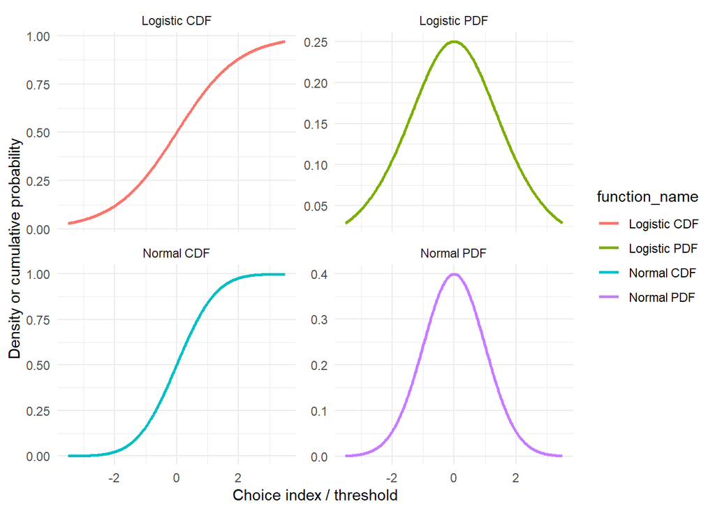

```r
z <- seq(-3.5, 3.5, length.out = 300)
curves <- rbind(
  data.frame(z, value = dnorm(z), function_name = "Normal PDF"),
  data.frame(z, value = pnorm(z), function_name = "Normal CDF"),
  data.frame(z, value = dlogis(z), function_name = "Logistic PDF"),
  data.frame(z, value = plogis(z), function_name = "Logistic CDF")
)
ggplot(curves, aes(z, value, colour = function_name)) +
  geom_line(linewidth = 1) + facet_wrap(~ function_name, scales = "free_y") +
  labs(x = "Choice index / threshold", y = "Density or cumulative probability") +
  theme_minimal()
```

**Pause:** Point to a steep and a flat part of each CDF.  
Where is its PDF taller?  
Read off the two peak heights, 0.399 and 0.25: they are the R4 bounds and the source of the factor 1.6 in R1.  
Note also that the logistic has fatter tails, so the two links disagree most for extreme probabilities.  
The linear probability model does not enforce the $[0,1]$ range; we do not fit it today.